# Sampling

### Mahendra Mariadassou, INRAE <br> from original slides by Tristan Mary-Huard

### Shandong University, Weihai (CN)<br>Summer School 2022

# Technical results

### Mean and variance of a sum

## Refresher

Recall the following definitions/properties:

`$$\begin{align}
E[Y] &= \sum_{k=1}^K y_k P(Y = y_k) \\
V[Y] &= E\left[ \left(Y-E[Y]\right)^2\right]\\
     &= E[Y^2]-E[Y]^2\\
Cov(X,Y) &= E\left[ (X-E[X])(Y-E[Y]) \right]\\
         &= E[XY]-E[X]E[Y]\\
\end{align}$$`

What about:

- `\(f(Y)\)` for a general numeric function `\(f: \mathbb{R} \to \mathbb{R}\)`

- `\(aY + b\)` (when `\(a, b \in \mathbb{R}\)`)

- `\(f(X, Y)\)` for a general numeric function `\(f: \mathbb{R}^2 \to \mathbb{R}\)`

- `\(X + Y\)`, `\(XY\)`

## Expectation of `\(f(Y)\)`

Falling back to the definition, we have

$$
E[f(Y)] = \sum_{k=1}^K f(y_k) P(Y = y_k)
$$

In particular, the expectation of `\(aY + b\)` can be expressed simply as

$$
E[aY + b] = aE[Y] + b
$$

Proof:

## Expectation of `\(f(Y_1, Y_2)\)`

Falling back to the definition, we have

`$$\begin{align}
E[f(Y_1, Y_2)] & = \sum_{k_1=1}^{K_1} \sum_{k_2=1}^{K_2} f(y_{k_1}, y_{k_2}) P(Y_1 = y_{k_1}, Y_2 = y_{k_2})
\end{align}$$`

In particular, the expectation of `\(X + Y\)` can be expressed simply:

$$
E[Y_1 + Y_2] = E[Y_1] + E[Y_2]
$$

Proof:

## Another formula for the variance

Using the previous result, we have an alternative form for the variance:

$$
V[X] = E\left[ (X - E[X])^2 \right] = E[X^2] - E[X]^2
$$

Proof:

`$$\begin{align}
V[X] & = E\left[ (X - E[X])^2 \right] \\
& = E\left[ X^2 - 2XE[X] + E[X]^2 \right] \\
& = E[X^2] - 2E\left[XE[X]\right] + E[X]^2 \\
& = E[X^2] - 2E[X]E\left[X\right] + E[X]^2 \\
& = E[X^2] - 2E[X]^2+ E[X]^2 \\
& = E[X^2] - E[X]^2
\end{align}$$`

### Expectation of `\(Y_1 Y_2\)`

- The expectation of a sum of random variables is the sum of the expectations
- The expectation of a product is

- no simple formula in general (but important exceptions)
  - it depends on the covariance between `\(Y_1\)` and `\(Y_2\)`

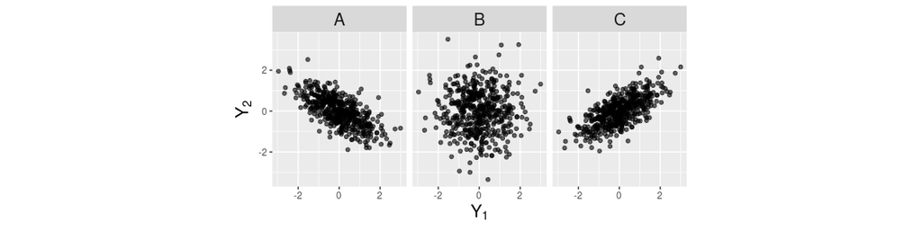

In each case, `\(E[Y_1] = 0\)` and `\(E[Y_2] = 0\)` but we have quizz1

- A: `\(E[Y_1 Y_2] = \dots\)`
- B: `\(E[Y_1 Y_2] = \dots\)`
- C: `\(E[Y_1 Y_2] = \dots\)`

- `\(E[Y_1 Y_2] = -0.48\)`
- `\(E[Y_1 Y_2] = -0.01\)`
- `\(E[Y_1 Y_2] = 0.47\)`

## Special case of independent variables

If `\(Y_1\)` and `\(Y_2\)` are independant, noted `\(Y_1 \perp Y_2\)`, the result is simpler...

`$$\begin{align}
E[Y_1 Y_2] &= \sum_{k_1=1}^{K_1} \sum_{k_2=1}^{K_2} y_{k_1} \times  y_{k_2} \underbrace{P(Y_1 = y_{k_1}, Y_2 = y_{k_2})}_{= P(Y_1 = y_{k_1}) \times P(Y_2 = y_{k_2})} \\
& = \sum_{k_1=1}^{K_1} \sum_{k_2=1}^{K_2} y_{k_1} \times  y_{k_2} P(Y_1 = y_{k_1}) \times P(Y_2 = y_{k_2}) \\
& = \sum_{k_1=1}^{K_1} \sum_{k_2=1}^{K_2} y_{k_1}P(Y_1 = y_{k_1}) \times  y_{k_2}P(Y_2 = y_{k_2}) \\
& = \left( \sum_{k_1=1}^{K_1} y_{k_1}P(Y_1 = y_{k_1}) \right) \times  \left( \sum_{k_2=1}^{K_2} y_{k_2}P(Y_2 = y_{k_2}) \right) \\
& = E[Y_1] \times E[Y_2]
\end{align}$$`

- In particular `\(Cov(Y_1, Y_2) = E[Y_1 Y_2] - E[Y_1]E[Y_2] = 0\)`
- More generally, `\(E[g_1(Y_1) \times g_2(Y_2)] = E[g_1(Y_1)] \times E[g_2(Y_2)]\)`

## Variance of a sum

Using the previous result, we have

$$
V(Y_1 + Y_2) = \dots
$$

`$$\begin{align}
V(Y_1 + Y_2) & = E\left[ (Y_1 + Y_2)^2 \right] - E\left[ Y_1 + Y_2 \right]^2 \\
& = E[Y_1^2] + 2E[Y_1 Y_2] + E[Y_2^2] - \left( E[Y_1]^2 + 2E[Y_1]E[Y_2] + E[Y_2]^2 \right) \\
& = \underbrace{E[Y_1^2] - E[Y_1]^2}_{=V(Y_1)} + 2 \underbrace{E[Y_1 Y_2] - E[Y_1]E[Y_2]}_{=Cov(Y_1, Y_2)} + \underbrace{E[Y_2^2] - E[Y_2]^2}_{=V(Y_2)} \\
& = V(Y_1) + 2Cov(Y_1, Y_2) + V(Y_2)
\end{align}$$`

In particular, if `\(Y_1 \perp Y_2\)`, then `\(V(Y_1 + Y_2) = V(Y_1) + V(Y_2)\)`.

## Sum of independent random variables

If `\(Y_1, \dots, Y_n\)` are i.i.d., the sum `\(S_n = Y_1 + \dots + Y_n\)` has very simple mean and variance:

Mean

$$
E[S_n] = E[Y_1 + \dots + Y_n] = E[Y_1] + \dots + E[Y_n] = nE[Y_1]
$$

Remark: The first equality is always true and the second requires identical means.

Variance

$$
V(S_n) = V[Y_1 + \dots + Y_n] = V[Y_1] + \dots + V[Y_n] = nV[Y_1]
$$

Remark: The equality requires independence and the second requires identical variances.

## Application to the Binomial distribution

Remember that a binomial variable `\(Y \sim \mathcal{B}(K, p)\)` is the sum of `\(K\)` independent Bernoulli trials:

$$
X = Y_1 + \dots + Y_K \quad \text{where the } Y_i \text{ are i.i.d. with } Y_i \sim \mathcal{B}(p)
$$

Using the previous results, it results that

`$$\begin{align}
E[X] & = K E[Y_1] = Kp \\
V[X] & = K V[Y_1] = Kp(1 -p)
\end{align}$$`

## Application to the Poisson distribution

We mentioned before that, if `\(X \sim \P(\lambda)\)`, then `\(V[X] = \lambda\)`. Remember that `\(E[X] = \lambda\)`.

`$$\begin{align}
V(X) & = E[X^2] - E[X]^2 \\
     &= E[X(X-1) + E[X] - E[X]^2 \\
     & = E[X(X-1)] + E[X] - E[X]^2 \\
     & = \lambda^2 + \lambda - \lambda^2 \\
     & = \lambda
\end{align}$$`

# A first try at estimation

## Finite population

### The Circle dataset

- Population of `\(n = 100\)` circles

- Indexed by `\(i = 1, \dots, n\)`

- Each characterized by its diameter `\(D_i\)`

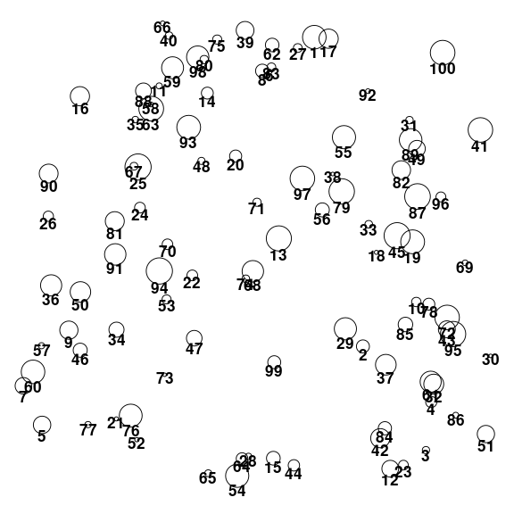

## List of diameters

| ID | Size |
| --- | --- |
| 1 | 8.9620360690169 |
| 2 | 4.78728718613274 |
| 3 | 2.5340078168083 |
| 4 | 4.06236454402097 |
| 5 | 6.54159525432624 |
| 6 | 1.46090941620059 |
| 7 | 6.17242016922683 |
| 8 | 4.9757195150014 |
| 9 | 6.84885584842414 |
| 10 | 3.36073757871054 |

[output cut: 90 more lines]

Goal: Provide an **estimate** of the mean circle diameter `\(E[D]=\mu_D\)`.

## Obtaining an estimate

Requires three steps:

- Step 1 Collect some data, i.e. a **sample**

- Step 2 Apply some **estimator** to the sample

- Step 3 Get the estimate:

- `\(D_1,...,D_n\)` collected *at random*

- `\(\overline{D}= \frac{1}{n} \sum_{i=1}^{n}D_i\)`

- `\(\widehat{\mu}_D= \frac{1}{n} \sum_{i=1}^{n}d_i\)`

The estimator is a random variable, the estimate is a numeric value

## Remarks and questions

One remark...

- ALWAYS distinguish between the true expectation `\(\mu_D\)` and its estimate `\(\widehat{\mu}_D\)`.

... and three questions

- Any (implicit) **assumption** about the way data were **collected** ?

- We defined an intuitive estimator: is it a good one ? How can we **assess** its **performance** ?

- If intuition fails to provide an estimator (or a good one), can we think of a **systematic strategy** to obtain a *good* estimator ?

## Several ways to "sample at random"

In the Circle example, one can

- Select the circles "by eye",

- Use the droppin' pen technics,

- Select identifiers at random,

- Any other meaningful strategy

Definition A **S**imple **R**andom **S**ampling is such that all samples of size `\(n\)` have the same probability `\({n \choose N}^{-1}\)` to be drawn.

Property: In a SRS, each individual has the same probability `\(n/N\)` to be selected.

## Applying SRS to the Circle dataset

Here are the estimates obtained from 32 SRS trials, with `\(n=10\)`:

`$$\displaystyle{\frac{1}{10}\sum_{i=1}^{10}d_i}=$$`

```
    Estimate 01: 5.3076	Estimate 02: 5.8976	Estimate 03: 3.8780	Estimate 04: 4.1243
    Estimate 05: 5.0101	Estimate 06: 4.5968	Estimate 07: 5.5176	Estimate 08: 4.2012
    Estimate 09: 6.0778	Estimate 10: 6.3875	Estimate 11: 6.4796	Estimate 12: 6.4881
    Estimate 13: 4.3832	Estimate 14: 5.9892	Estimate 15: 5.3621	Estimate 16: 5.3960
    Estimate 17: 5.3632	Estimate 18: 4.2552	Estimate 19: 6.8789	Estimate 20: 4.7823
    Estimate 21: 5.6886	Estimate 22: 5.2215	Estimate 23: 6.9647	Estimate 24: 6.7541
    Estimate 25: 5.4322	Estimate 26: 4.9458	Estimate 27: 4.6955	Estimate 28: 5.4238
    Estimate 29: 6.0931	Estimate 30: 3.8522	Estimate 31: 4.9817	Estimate 32: 5.2376
```

*True mean:* 5.427

Remark: One cannot evaluate the performance of an estimator through an estimate since the estimate depends both on the estimator **and** the sample.

Performance has to be evaluated **on average** over **all** possible samples

## Performance evaluation

Estimator `\(\overline{D}\)` is a random variable (which depends on the sample).

One can define:
- the bias `\(B(\overline{D}) = E[\overline{D}]-\mu_D\)`
- the variance `\(V(\overline{D})\)`.

Mean Square Error

One defines `$$MSE(\overline{D}) = E[(\overline{D}-\mu_D)^2].$$`

Remark How is `\(MSE(\overline{D})\)` related to bias and variance ?

`$$MSE(\overline{D}) = B^2(\overline{D}) + V(\overline{D})$$`

Why is all of this useful at all ? quizz2

# SRS in finite population

## General framework

Consider a population `\(\mathcal{P}\)` of size `\(N\)` and note `\(y_i\)` the value of variable `\(Y\)` measured on individual `\(i\)`.

Define

`$$\begin{eqnarray*}
E[Y] &=& \frac{1}{N}\sum_{i=1}^{N}y_i  =\mu\\
\text{and } V[Y] &=& \frac{1}{N}\sum_{i=1}^{N}(y_i-\mu)^2 = \sigma^2
\end{eqnarray*}$$`

Assume `\(\mu\)` is estimated by applying the empirical mean to sample `\(S\)`:
`$$\begin{equation}
\overline{Y} = \frac{1}{n}\sum_{i\in S}Y_i = \frac{1}{n}\sum_{i=1}^{N}\varepsilon_i y_i
 \quad \text{where} \quad \varepsilon_i = \begin{cases}
1 & \text{if } i\in S \\
0 & \text{otherwise}
\end{cases}
\end{equation}$$`

Remark `\(n\)` (sample) is generally much smaller than `\(N\)` (population) !!

## Theoretical properties of `\(\overline{Y}\)`

Consider a SRS, i.e. `\(P(S)={n \choose N}^{-1}\)`, then

`$$\begin{eqnarray*}
E[\overline{Y}] &=& \mu \\
V[\overline{Y}] &=& \frac{1}{n}\left(1-\frac{n}{N}\right)\frac{N}{N-1}\sigma^2 =\frac{1}{n}\left(1-\frac{n}{N}\right)(\sigma^*)^2
\end{eqnarray*}$$`

where `\((\sigma^*)^2= \frac{N}{N-1}\sigma^2\)` is the corrected population variance (more on that later) quizz3

Application to the circle dataset:
`\(N=100\)`, `\(n=10\)`, `\(\sigma^2\)`=7.779

`\(\Rightarrow V[\overline{Y}] =\frac{1}{10}\times\frac{100}{99}\times\left(1-\frac{10}{100}\right)\times\)` 7.779 = 0.707

## Proof

## Stratified sampling

Assume that population `\(\mathcal{P}\)` has `\(H\)` strata `\(\mathcal{P}_1,...,\mathcal{P}_H\)`.

Define

- `\(N_h\)`: size of stratum `\(\mathcal{P}_h\)`, `\(h=1,...,H\)`,

- `\(N=\sum_h N_h\)`: population size,

- `\(\mu_h=\frac{1}{N_h}\sum_{i\in\mathcal{P}_h}y_i\)`: mean of stratum `\(h\)`,

- `\(\sigma_h^*=\frac{1}{N_h-1}\sum_{i\in\mathcal{P}_h}(y_i-\mu_h)^2\)`: corrected variance of stratum `\(h\)`.

Stratified sampling

Perform one SRS per stratum where

- `\(n_h\)`: number of sampled individuals per stratum,

- `\(n=\sum_h n_h\)`: total sample size,

- `\(\overline{Y}_h=\frac{1}{n_h}\sum_{i\in\mathcal{P}_h}Y_i\)`: empirical mean of stratum `\(h\)`.

One then estimates the population mean `\(\mu\)` using
`$$\overline{Y}_{St} = \sum_{h=1}^{H}\frac{N_h}{N}\overline{Y}_h$$`

## Properties of stratified sampling

Consider a stratified sampling strategy. Then

`$$\begin{eqnarray*}
E[\overline{Y}_{St}] &=& \mu \\
V[\overline{Y}_{St}] &=&
\sum_{h=1}^H \left(\frac{N_h}{N}\right)^2\times \frac{1}{n_h}\left(1-\frac{n_h}{N_h}\right) \times (\sigma_h^*)^2 \\
V[\overline{Y}_{St}] &\leq& V[\overline{Y}]
\end{eqnarray*}$$`

Proof: based on the properties of SRS (equalities) and on the decomposition of the population variance + assuming `\(\frac{N_h-1}{N_h}\approx1\)` (inequality).

## Proof

# IID sampling in infinite populations

## Sampling in an infinite population

Consider a population `\(\mathcal{P}\)` where variable `\(Y\)` has distribution `\(\mathcal{L}\)`.
Define
$$E[Y] = \mu, \quad V[Y] =\sigma^2 $$

Assume `\(\mu\)` is estimated by applying the empirical mean to sample `\(Y_1,...,Y_n\)`, where
`$$Y_i \sim \mathcal{L}, \text{ i.i.d.}$$`
Then
$$E\left[\overline{Y}\right] = \mu,\quad V\left[\overline{Y}\right] = \frac{\sigma^2}{n} $$

quizz4

Proof: Your turn!

# Exercises

## Exercise 1: Bulb lifetime

A bulb manufacturer claims that 90% of the produced bulbs have a lifetime of 500 hours or higher. An investigator bought 12 bulbs and obtained the following lifetimes:

```
536 490 510 572 564 537 549 535 549 528 569 533
```

Assuming bulb lifetimes have a Poisson distribution:

- What is the average lifetime of the produced bulbs?
- Is the manufacturer honest ?

Answers

`\(\widehat{E[L]} =\widehat{\lambda}=\)` 539.333,

`\(\quad \widehat{P}_{\widehat{\lambda}}(L\geq 500)=\)` 0.954

## Exercise 2: Exponential distribution

A a positive real valued random variable `\(X\)` has a exponential distribution `\(\mathcal{E}(\lambda)\)` with parameter `\(\lambda\)`, noted `\(X\sim\mathcal{E}(\lambda)\)`, if

$$f_X(x) = \lambda e^{-\lambda x}, \ x\geq0, \ \lambda\geq0. $$

- Check that `\(\int_0^\infty f(t)dt = 1\)` (i.e. `\(f\)` is a density function).

- Compute `\(E[X]\)`, where `\(X\sim\mathcal{E}(\lambda)\)`.

- Assuming `\(X_1,...X_n\sim\mathcal{E}(\lambda)\)` i.i.d., suggest an estimator for `\(\lambda\)`.

## Summary

3 quantities to distinguish

- `\(\mu=E[X]\)`: true population mean.
- `\(\overline{Y}=\frac{1}{n}\sum_{i=1}^nY_i\)`: estimator.
- `\(\widehat{\mu}=\frac{1}{n}\sum_{i=1}^ny_i\)`: estimate.

Remember that estimator `\(\neq\)` estimate

Sampling

- In the following, we will always assume either SRS (finite pop.) or i.i.d. sampling (infinite pop.).

Performance

- Different estimators can be compared through their MSE.
- Keep in mind that `\(MSE(T) = B^2(T) + V(T)\)`

What's next ?

- What if intuition fails to provide an estimator (or a good one)?
- `\(\Rightarrow\)` Need for a *systematic strategy* to obtain a satisfactory estimator!